# Class Activity, August 30

In this activity, you will practice using `ggplot` to create and customize visualizations. You will use both the `mpg` data from class today, and the `penguins` data from last week. Work in groups to answer the questions below. Solutions are provided for the first two questions, in case you get stuck.

## Setup

As with all class activities, there is nothing you will need to submit. However, in case it helps you work on the questions, an R Markdown template is provided for you: [activity template](https://sta112-f21.github.io/class_activities/ca_lecture_4_template.Rmd)

The `mpg` data comes from the `tidyverse` package, and the `penguins` data comes from the `palmerpenguins` package. You will need to load each of these packages (with `library`) to run the code today. If you use the R Markdown template, those packages are included in the setup chunk, so you just need to run the setup chunk first.

## Questions

1. Fill in the following code to create the scatterplot below (each `...` needs to be filled in):

```r
mpg %>%
  ggplot(aes(x = cty, y = hwy, color = class)) +
  geom_point() +
  facet_wrap(~year) +
  labs(x = "...",
       y = "...",
       color = "...") +
  theme_...()
```

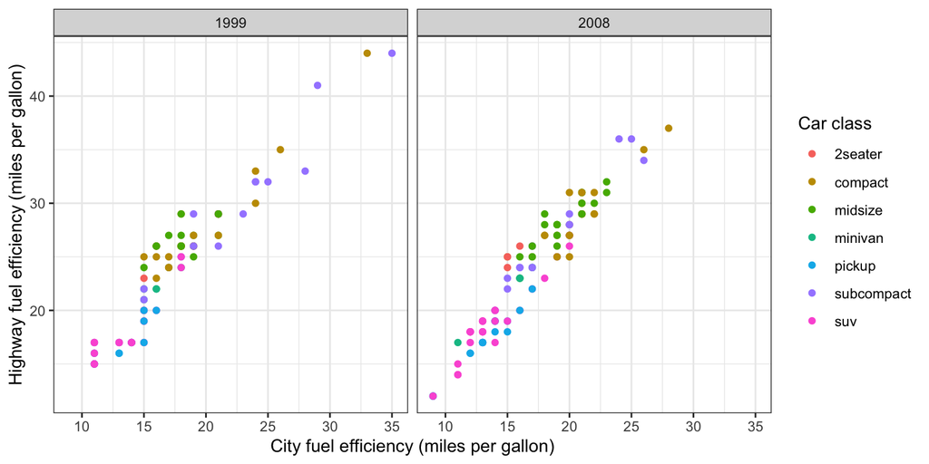

```r
mpg %>%
  ggplot(aes(x = cty, y = hwy, color = class)) +
  geom_point() +
  facet_wrap(~year) +
  labs(x = "City fuel efficiency (miles per gallon)",
       y = "Highway fuel efficiency (miles per gallon)",
       color = "Car class") +
  theme_bw()
```

2. Fill in the following code to create the boxplots below (each `...` needs to be filled in):

```r
penguins %>%
  ggplot(aes(x = ..., y = ...)) +
  geom_...() +
  labs(x = "...",
       y = "...",
       title = "...") +
  theme_...()
```

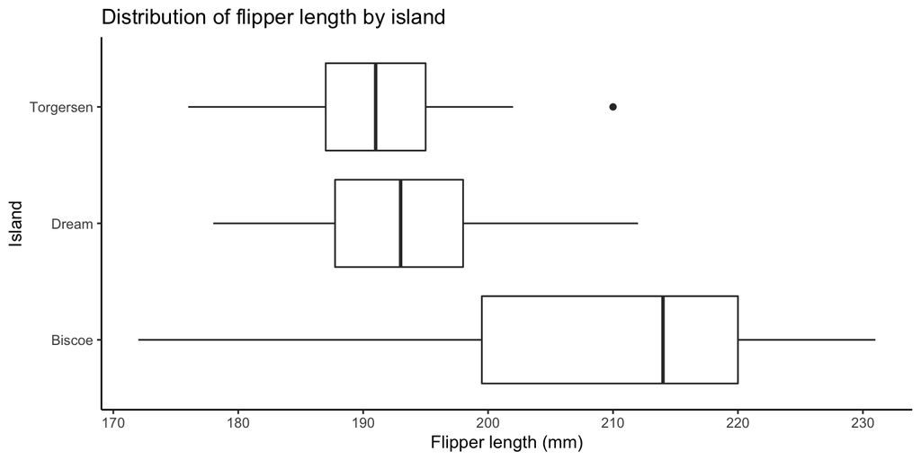

```r
penguins %>%
  ggplot(aes(x = flipper_length_mm, y = island)) +
  geom_boxplot() +
  labs(x = "Flipper length (mm)",
       y = "Island",
       title = "Distribution of flipper length by island") +
  theme_classic()
```

3. Recreate this scatterplot using the `penguins` data. You may find the `ggplot2` cheatsheet [(click here)](https://raw.githubusercontent.com/rstudio/cheatsheets/master/data-visualization.pdf) helpful.

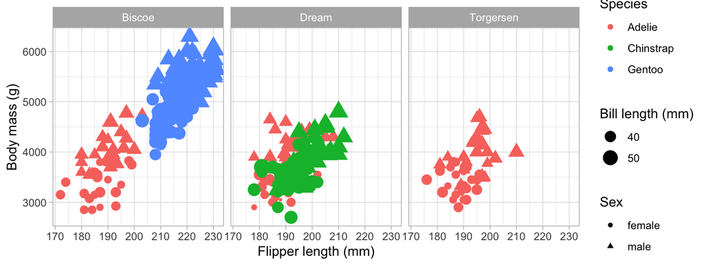

4. A researcher looks at the boxplots from Exercise 2, and hypothesizes that living on different islands causes penguins to have different flipper lengths. Explain why their reasoning is flawed.